# La Sauce - Historique

À l’approche du 100<sup>è</sup> match de la Sauce, un petit retour sur les différentes statistiques accumulées jusqu’ici s’impose. À partir des données issues du [site de la LRF](https://www.lrf.ch/equipe.php?id=304), on dispose de suffisamment d’informations pour dresser un petit portrait général des résultats. On peut ainsi retracer les scores, les dynamiques au niveau des buts marqués et encaissés ainsi que les résultats contre les adversaires récurrents.

Faute d’avoir compilé nos propres statistiques sur les buteurs et passeurs décisifs ainsi que le type d’action (dans le jeu, balle arrêtée, etc.) ayant conduit aux buts, les individualités ressortent grâce à l’analyse des sanctions en fin de document. Finalement, un petit aperçu de l’expérience géographique en LRF conclut l’analyse.

## Analyse générale des résultats

Depuis 2013, La Sauce a eu 110 matchs au programme en LRF. Sur tous ces matchs, 99 ont été joués alors que 8 ont été décidés par forfait et 3 simplement annulés.

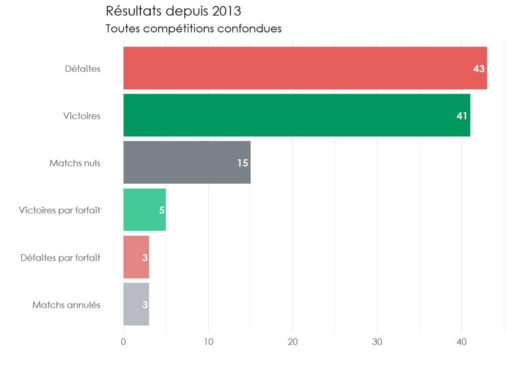

La Sauce dispute le championnat régulier de la LRF ainsi que la coupe, avec 6 participations (9 matches).

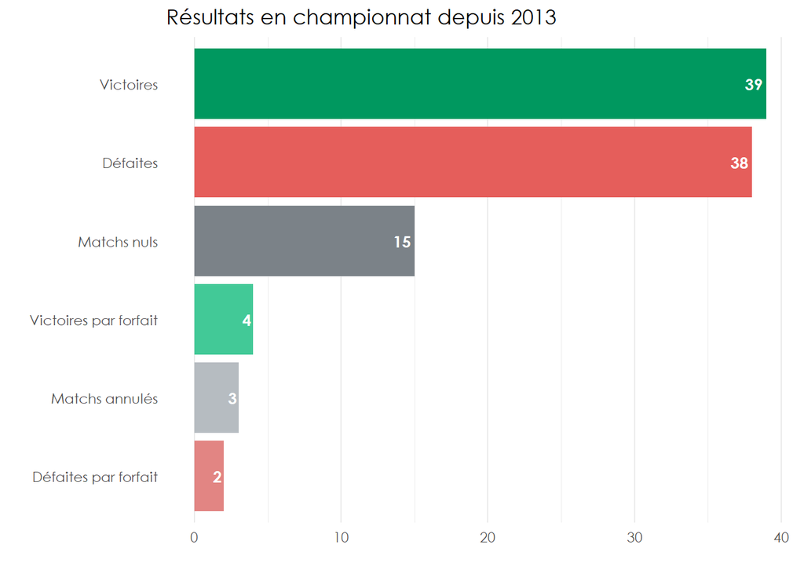

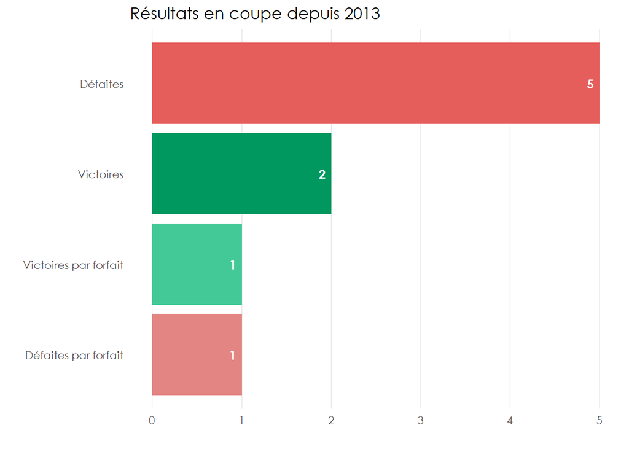

À cause du caractère aléatoire du tirage de la coupe, le reste de l’analyse se base sur les 92 matchs de championnat joués en 11 saisons.

### Scores

Au niveau des scores des matchs, on a une grande diversité avec 45 scores différents obtenus en 92 matchs dont 23 scores qui ne sont arrivés qu’une seule fois. Ci-dessous, un résumé du top 3 des scores les plus fréquents:

```
2-1, 6 victoires
3-2, 6 victoires
1-1, 5 nuls
3-3, 5 nuls
1-3, 4 défaites
1-4, 4 défaites
2-2, 4 nuls
```

Le graphique suivant reprend la distribution des différents scores avec en *x* les buts marqués par La Sauce et en *y* ceux encaissés. On peut notamment voir qu’il n’y a jamais eu de 0-0 en plus de 10 ans.

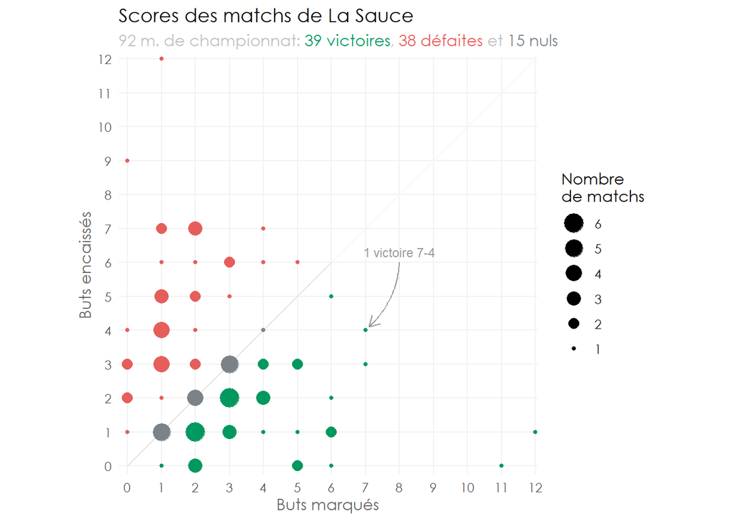

### Buts

Depuis ses débuts, La Sauce a marqué 250 fois et encaissé 274 buts, soit une différence de -24. Au niveau des **buts pour**, la moyenne est à 2.72 alors que la médiane est de 2, signe que quelques matchs avec beaucoup de buts tirent la moyenne vers le haut. Pour les **buts contre**, on semble les encaisser de façon plus constante avec une moyenne de 2.98 et une médiane de 3.

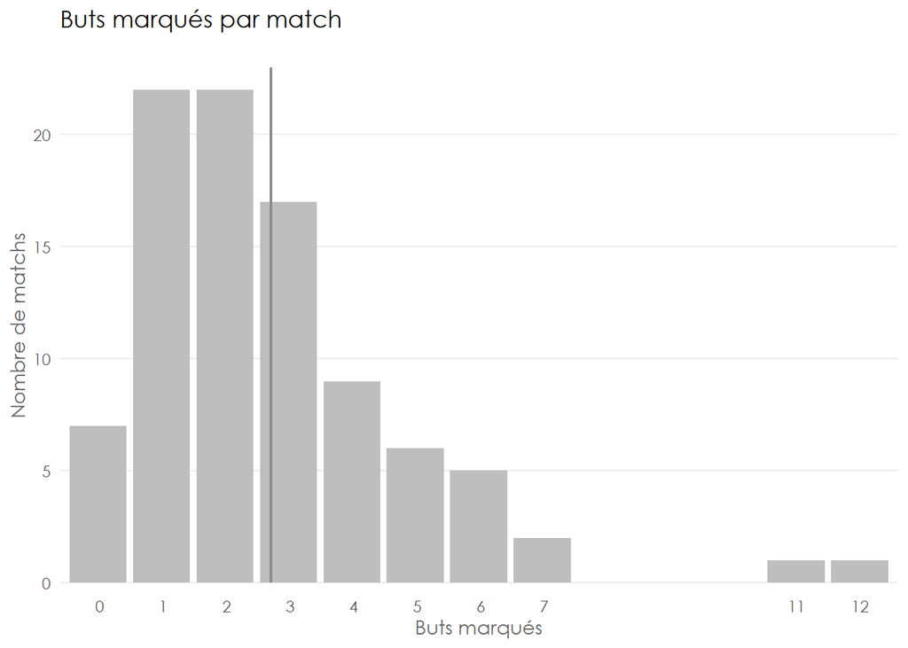

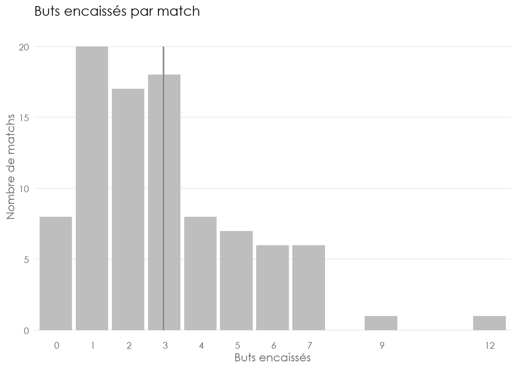

Les victoires serrées sont une marque de fabrique de La Sauce, avec les deux marges de victoire les plus fréquentes qui sont de seulement 1 but (16 matchs) et 2 buts (11 matchs) !

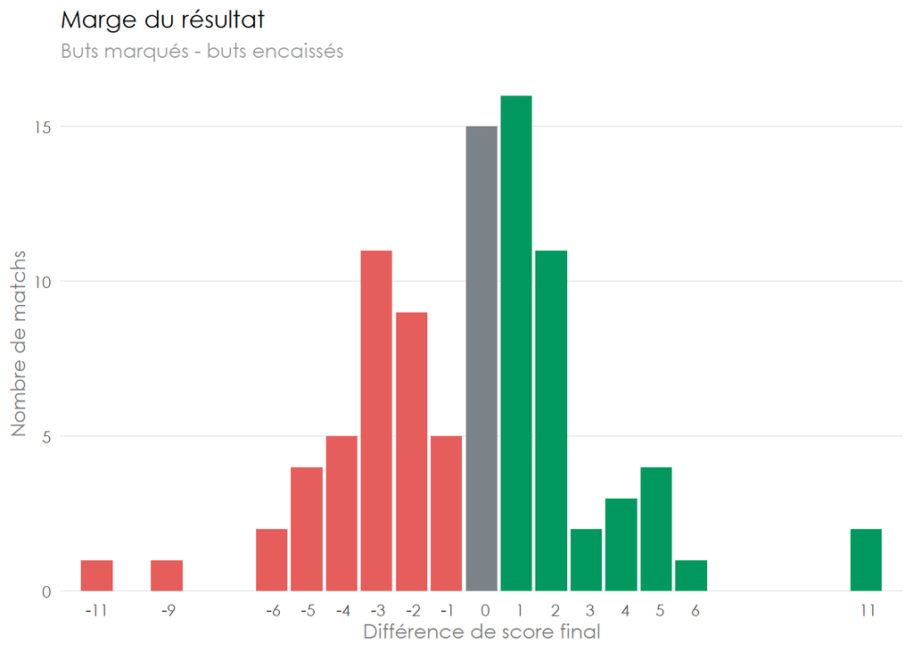

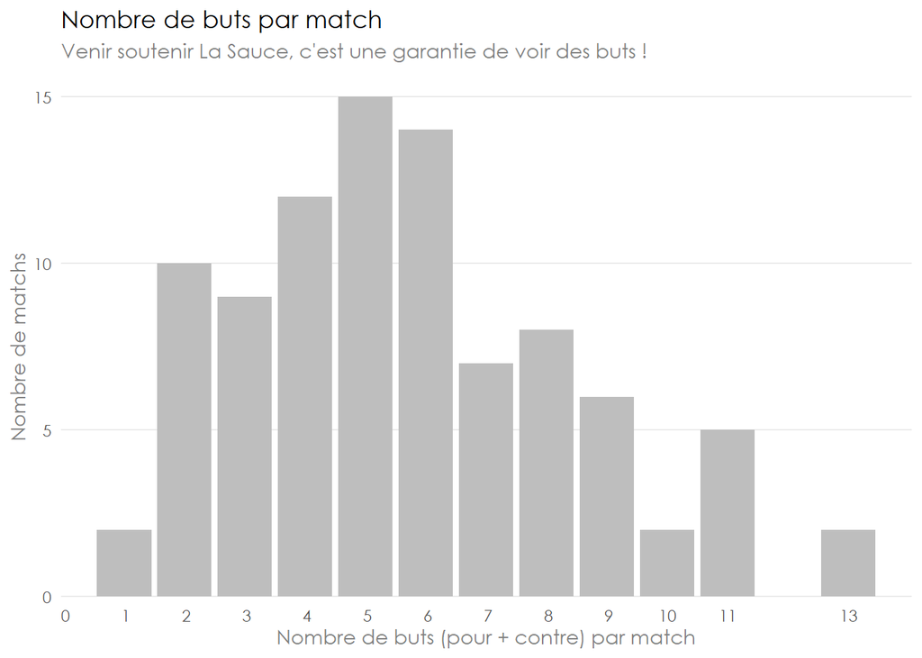

## Résultats par saison

La Sauce a joué 11 saisons depuis 2013. Les formes du championnat (groupes avec matchs aller-retour, matchs uniques, nombre d’équipes par groupes, demi-groupes pendant le covid) variant fortement d’une année à l’autre, il est assez compliqué de tirer des parallèles.

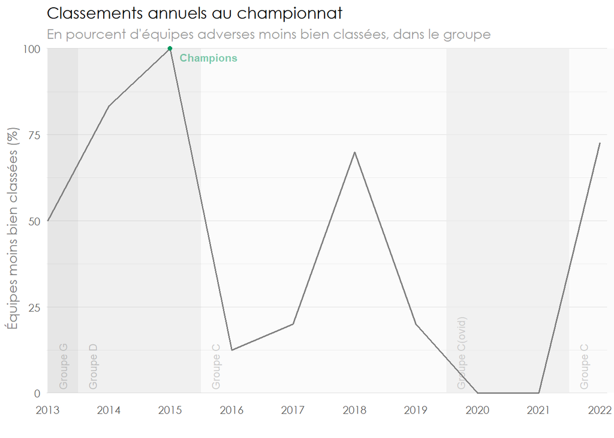

Le tableau suivant résume les principales infos (victoires, nuls, défaites, buts pour, buts contre, moyenne des buts pour, moyenne des buts contres, notre position au classement et le nombre d’équipes du groupe) pour chacune des saisons

Statistiques des 11 saisons

Résultats, buts et classements

| Saison | V | N | D | Bp | Bc | Mbp | Mbc | Cla | Nb_eq |
| --- | --- | --- | --- | --- | --- | --- | --- | --- | --- |
| 2013 | 5 | 0 | 5 | 30 | 29 | 3 | 2.9 | 4 | 7 |
| 2014 | 8 | 2 | 2 | 42 | 22 | 3.5 | 1.8 | 3 | 13 |
| 2015 | 5 | 2 | 1 | 24 | 15 | 3 | 1.9 | 1 | 12 |
| 2016 | 0 | 4 | 3 | 15 | 19 | 2.1 | 2.7 | 8 | 9 |
| 2017 | 3 | 1 | 6 | 23 | 36 | 2.3 | 3.6 | 9 | 11 |
| 2018 | 6 | 2 | 2 | 33 | 19 | 3.3 | 1.9 | 4 | 11 |
| 2019 | 2 | 1 | 7 | 15 | 41 | 1.5 | 4.1 | 9 | 11 |
| 2020 | 0 | 0 | 3 | 3 | 17 | 1 | 5.7 | 5 | 5 |
| 2021 | 1 | 1 | 2 | 7 | 20 | 1.8 | 5 | 4 | 4 |
| 2022 | 7 | 0 | 4 | 42 | 37 | 3.8 | 3.4 | 4 | 12 |

[output cut: 1 more lines]

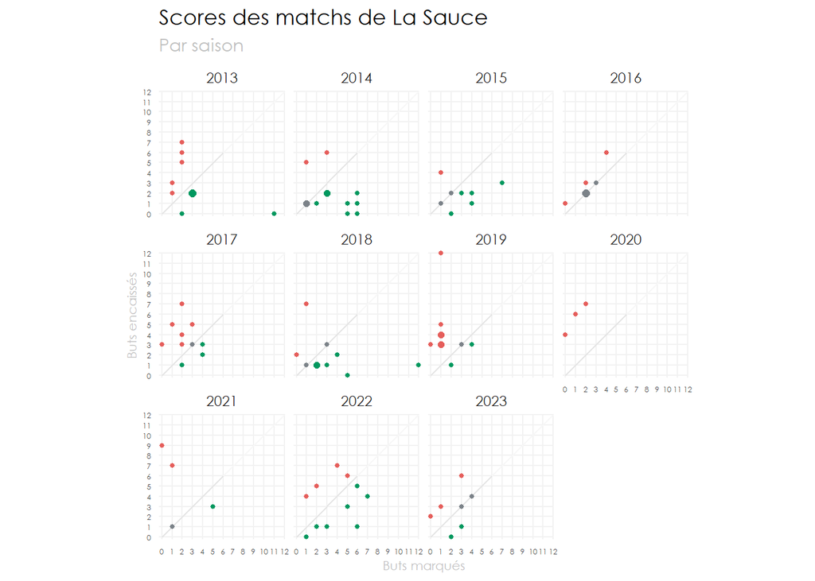

## Adversaires

Au fil des années, nous avons affronté 36 équipes différentes en championnat dont 14 contre lesquelles un seul match a été disputé. Le graphique ci-dessous résume les résultats obtenus pour les équipes affrontées 3 fois ou plus.

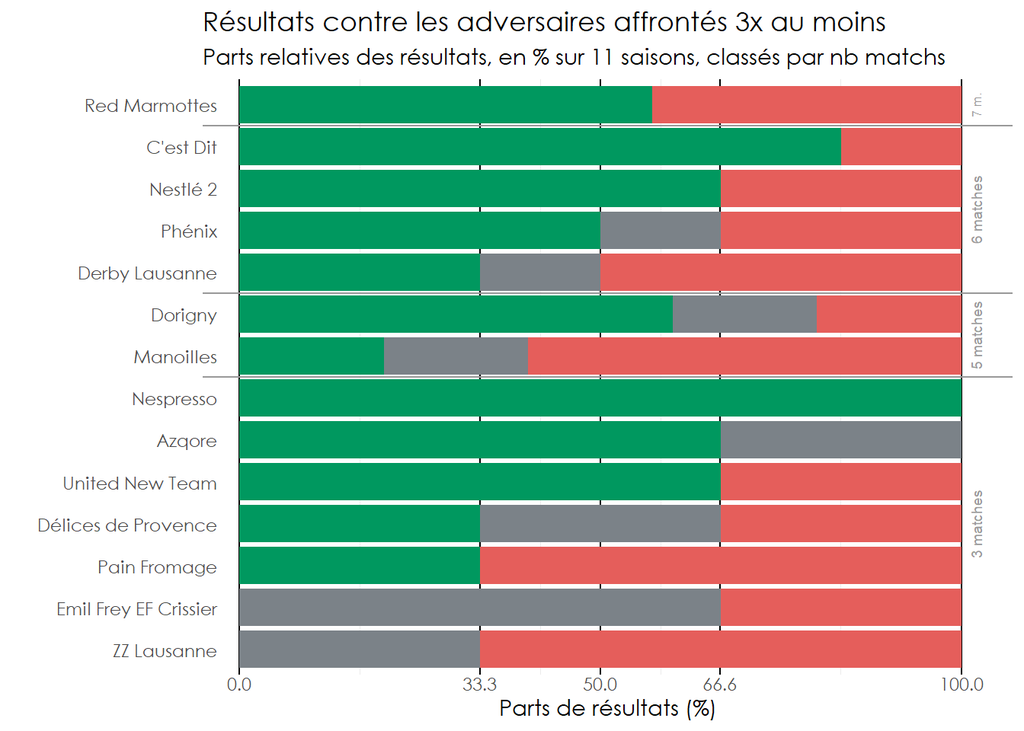

## Discipline

Les données concernant la discipline sont disponibles uniquement depuis la saison 2017… En 6 ans, 11 joueurs différents se sont pris un total de 17 cartons (16 jaunes et 1 rouge). Le montant total des amendes payées est de 370.- CHF et représente également 52 points pris au classement fair-play.

On retrouve ci-dessous les joueurs avertis ou expulsés alors que le graphique d’après détaille les motifs.

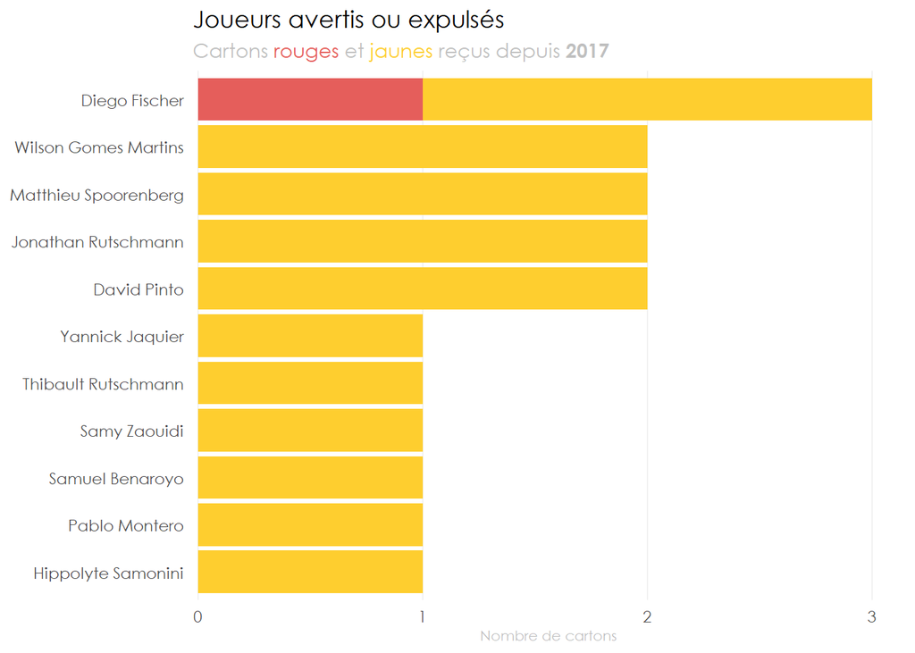

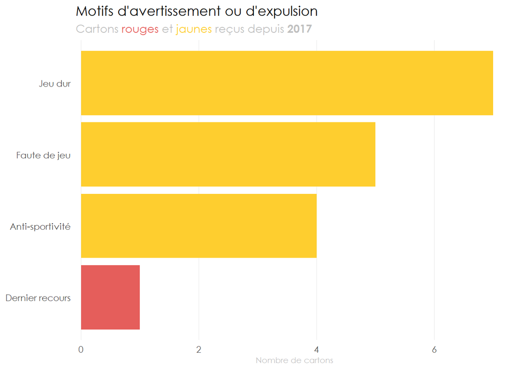

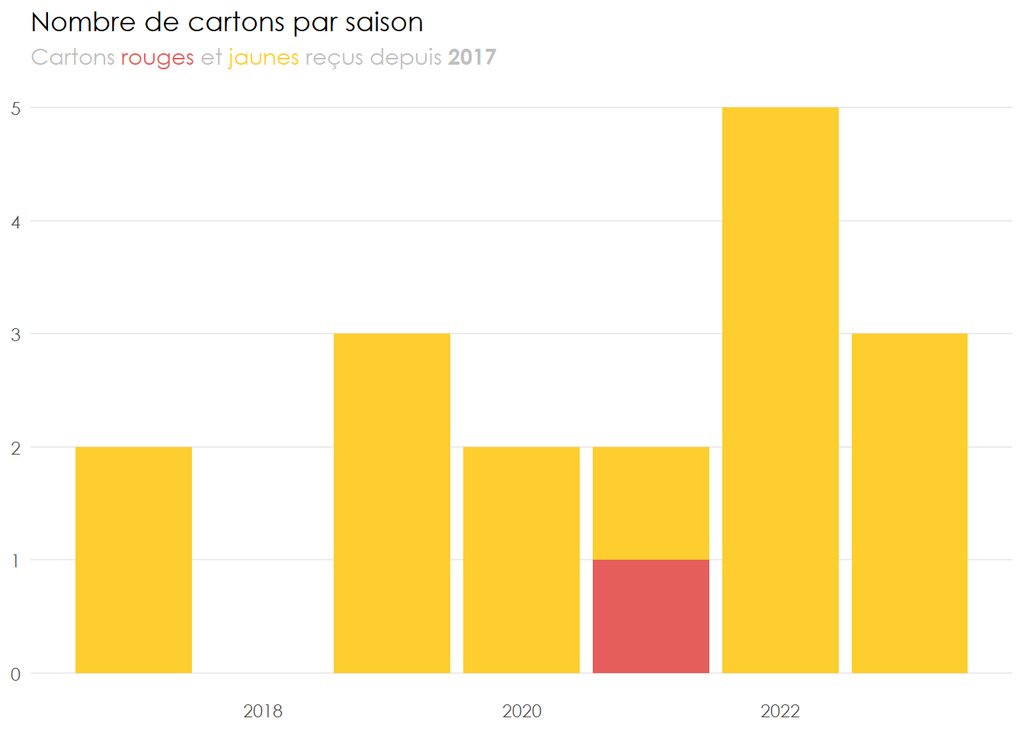

## Terrains

Depuis 2013, on a eu l’occasion de jouer à 7 emplacements différents. Le Chalet-à-Gobet (ChàG) reste le terrain principal de nos exploits (85.9% des matchs de championnat).

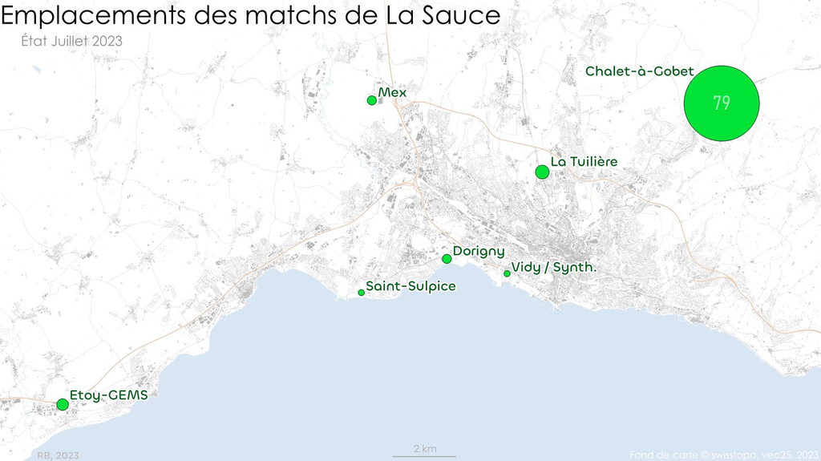